# Reproducible Research: Peer Assessment 1

This project examines data from a personal activity monitoring device. The data covers the months of October and November, 2012, and it consists of the number of steps taken in each 5-minute interval in those months.

## Loading and preprocessing the data

The data consists of three columns:

- Steps: #steps taken
- Date: date of observation
- Interval: minute of day corresponding to start of 5-minute interval of observation

```r
obs.data <- read.csv("activity.csv", header=TRUE,
                     colClasses=c("integer", "Date", "integer"))
summary(obs.data)
```

```
##      steps            date               interval
##  Min.   :  0.0   Min.   :2012-10-01   Min.   :   0
##  1st Qu.:  0.0   1st Qu.:2012-10-16   1st Qu.: 589
##  Median :  0.0   Median :2012-10-31   Median :1178
##  Mean   : 37.4   Mean   :2012-10-31   Mean   :1178
##  3rd Qu.: 12.0   3rd Qu.:2012-11-15   3rd Qu.:1766
##  Max.   :806.0   Max.   :2012-11-30   Max.   :2355
##  NA's   :2304
```

The time for the interval data is stored in the format HHMM, which is very misleading when plotted as an integer. So we convert it into the format mmmm, which is the number of minutes since midnight.

```r
obs.data$interval <- 60 * (obs.data$interval %/% 100) + (obs.data$interval %% 100)
summary(obs.data)
```

```
##      steps            date               interval
##  Min.   :  0.0   Min.   :2012-10-01   Min.   :   0
##  1st Qu.:  0.0   1st Qu.:2012-10-16   1st Qu.: 359
##  Median :  0.0   Median :2012-10-31   Median : 718
##  Mean   : 37.4   Mean   :2012-10-31   Mean   : 718
##  3rd Qu.: 12.0   3rd Qu.:2012-11-15   3rd Qu.:1076
##  Max.   :806.0   Max.   :2012-11-30   Max.   :1435
##  NA's   :2304
```

## What is mean total number of steps taken per day?

The first question to be answered is the mean total number of steps taken per day. To find this, first compute the total number of steps taken each day, then average the results.

```r
obs.by.date <- aggregate(steps ~ date, obs.data, sum)
summary(obs.by.date)
```

```
##       date                steps
##  Min.   :2012-10-02   Min.   :   41
##  1st Qu.:2012-10-16   1st Qu.: 8841
##  Median :2012-10-29   Median :10765
##  Mean   :2012-10-30   Mean   :10766
##  3rd Qu.:2012-11-16   3rd Qu.:13294
##  Max.   :2012-11-29   Max.   :21194
```

As you can see, the **mean** total number of steps taken per day is 10766.19, and the **median** is 10765. The following figure gives a better overview of the distribution.

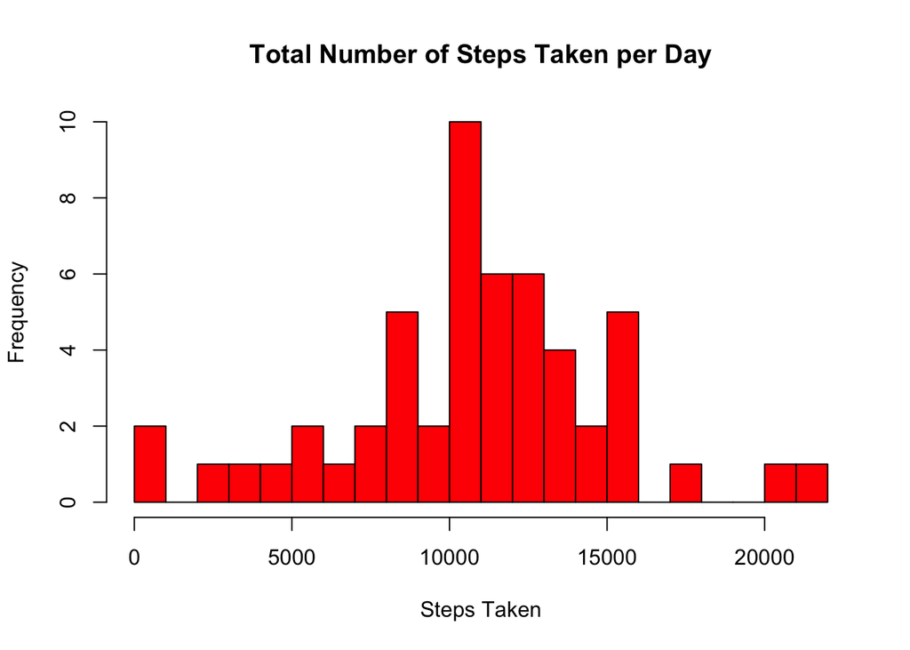

```r
hist(obs.by.date$steps, breaks=20, col="red",
     main="Total Number of Steps Taken per Day",
     xlab="Steps Taken", ylab="Frequency")
```

## What is the average daily activity pattern?

The next question concerns the average daily activity pattern, or how the activities varies by time. This is best seen in a line graph, after averaging the data by time of day.

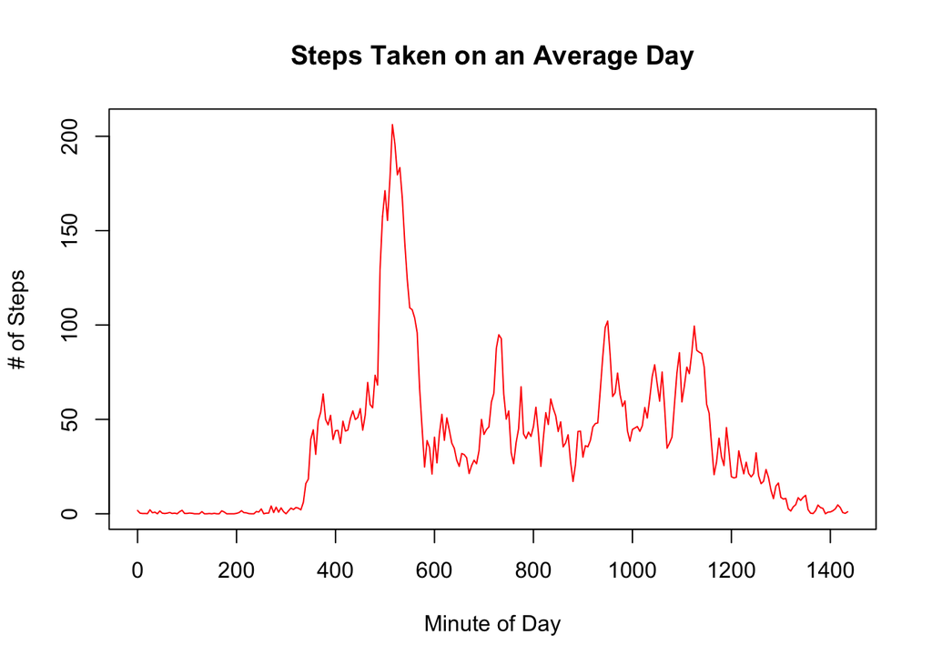

```r
obs.by.interval <- aggregate(steps ~ interval, obs.data, mean)
plot(obs.by.interval, type="l", col="red",
     main="Steps Taken on an Average Day",
     xlab="Minute of Day",
     ylab="# of Steps")
```

From the graph, it is clear that **peak activity** occurs around the 500th minute, or 8am. Analytically, we can also find the actual interval with the peak activity and convert it to a time as follows.

```r
idx <- which.max(obs.by.interval$steps)
minute <- obs.by.interval[idx, "interval"]
paste ((minute %/% 60), (minute %% 60), sep=":")
```

```
## [1] "8:35"
```

## Imputing missing values

Unfortunately, the data has a lot of missing values. As the following table shows, there are 2304 **missing values** in the steps column. The other columns do not contain any missing values.

```r
summary(obs.data)
```

```
##      steps            date               interval
##  Min.   :  0.0   Min.   :2012-10-01   Min.   :   0
##  1st Qu.:  0.0   1st Qu.:2012-10-16   1st Qu.: 359
##  Median :  0.0   Median :2012-10-31   Median : 718
##  Mean   : 37.4   Mean   :2012-10-31   Mean   : 718
##  3rd Qu.: 12.0   3rd Qu.:2012-11-15   3rd Qu.:1076
##  Max.   :806.0   Max.   :2012-11-30   Max.   :1435
##  NA's   :2304
```

There are different ways of eliminating these missing values, such as filling with the previous known value or using an average. For this study, it makes sense to fill with the median value based on the time interval. There is great variability based on the time of day, so that definitely should be taken into account. Moreover, the median is more robust in the prescence of outliers, such as a day walking at the park or relaxing at the beach. The effect is easily seen in a histogram as follows. The big change is that there now a significant number of days when between 1,000 and 2,000 steps were taken.

```r
obs.by.interval.median <- aggregate(steps ~ interval, obs.data, median)
obs.data.fill <- merge(x = obs.data,
                       y = obs.by.interval.median,
                       by = "interval")
obs.data.fill$steps <- obs.data.fill$steps.x
obs.data.fill$steps.x <- NULL
nans <- which(is.na(obs.data.fill$steps))
obs.data.fill$steps[nans] <- obs.data.fill$steps.y[nans]
obs.data.fill$steps.y <- NULL
summary(obs.data.fill)
```

```
##     interval         date                steps
##  Min.   :   0   Min.   :2012-10-01   Min.   :  0
##  1st Qu.: 359   1st Qu.:2012-10-16   1st Qu.:  0
##  Median : 718   Median :2012-10-31   Median :  0
##  Mean   : 718   Mean   :2012-10-31   Mean   : 33
##  3rd Qu.:1076   3rd Qu.:2012-11-15   3rd Qu.:  8
##  Max.   :1435   Max.   :2012-11-30   Max.   :806
```

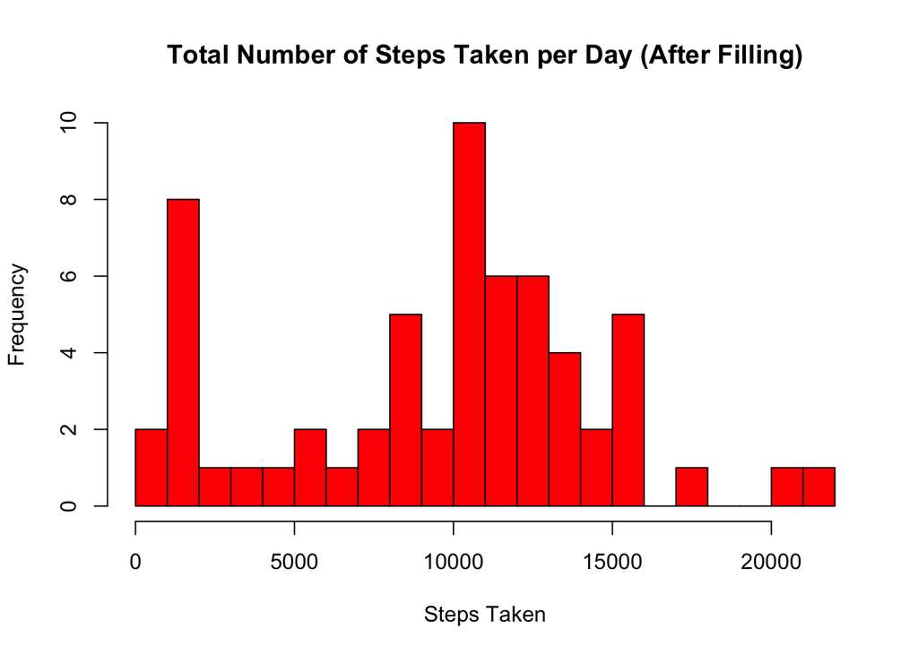

```r
obs.by.date.fill <- aggregate(steps ~ date, obs.data.fill, sum)
hist(obs.by.date.fill$steps, breaks=20, col="red",
     main="Total Number of Steps Taken per Day (After Filling)",
     xlab="Steps Taken", ylab="Frequency")
```

More analytically, the data can be summarized as follows.

```r
summary(obs.by.date.fill)
```

```
##       date                steps
##  Min.   :2012-10-01   Min.   :   41
##  1st Qu.:2012-10-16   1st Qu.: 6778
##  Median :2012-10-31   Median :10395
##  Mean   :2012-10-31   Mean   : 9504
##  3rd Qu.:2012-11-15   3rd Qu.:12811
##  Max.   :2012-11-30   Max.   :21194
```

Notice there are no missing values, and that the **mean** and **median** number of steps per day are now 9503.87 and 10395, respectively. Compared to the original values of 10766.19 and 10765, this confirms that the effect of removing the NA values is to illustrate the days in which between 1,000 and 2,000 steps were taken, which are considerably below the original mean and median.

## Are there differences in activity patterns between weekdays and weekends?

The final analysis concerns the effect of weekends on activity levels. First, each datapoint is classified as either corresponding to a weekday or weekend. Then, the data is separated using this classification, and each subset of the data is separately averaged. The result, which follows, is a graph clearly showing the different activity patterns on weekends.

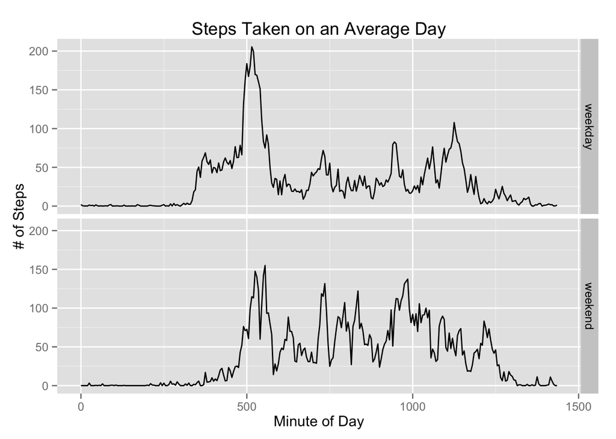

```r
obs.data.fill$weekday <- weekdays(obs.data.fill$date)
obs.data.fill$daytype <- "weekday"
obs.data.fill$daytype[obs.data.fill$weekday == 'Saturday'] <- "weekend"
obs.data.fill$daytype[obs.data.fill$weekday == 'Sunday']   <- "weekend"
obs.data.fill$daytype = factor(obs.data.fill$daytype)
obs.data.fill$weekday <- NULL

obs.data.fill.weekday <- subset(obs.data.fill, daytype == "weekday")
obs.data.fill.weekend <- subset(obs.data.fill, daytype == "weekend")

obs.by.interval.weekday <- aggregate(steps ~ interval,
                                     obs.data.fill.weekday,
                                     mean)
obs.by.interval.weekday$daytype <- "weekday"
obs.by.interval.weekend <- aggregate(steps ~ interval,
                                     obs.data.fill.weekend,
                                     mean)
obs.by.interval.weekend$daytype <- "weekend"
obs.by.interval.combined <- rbind(obs.by.interval.weekday,
                                 obs.by.interval.weekend)
obs.by.interval.combined$daytype <-
  factor(obs.by.interval.combined$daytype)


library(ggplot2)
ggplot(obs.by.interval.combined,
       aes(x=interval, y=steps)) +
  labs(title="Steps Taken on an Average Day",
       x="Minute of Day",
       y="# of Steps") +
  geom_line() +
  facet_grid(daytype ~ .)
```

As the graph clearly shows, less activity occurs in the early morning of weekends, as the subjects are more likely to sleep in. However, the activity overall is higher during the days on weekends than on weekdays, perhaps reflecting a sedentary workplace.